# slide_deck_template slides

The Loan Dataset from Prosper

Dataset exploration by LOKKAN CHENG

Preliminary Wrangling Overview of this dataset:

This dataset contains 113,937 loans with 81 variables on each loan, including loan amount, borrower rate (or interest rate), current loan status, borrower income, and many others.

The data dictionary docunment explains the variables in the data set.

More than 50% of people are employed and the lowest three are retired,part-time and not-employed.

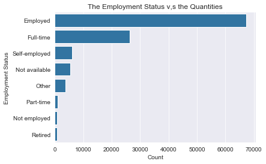

```python
#2. The Employment Status

order2 = df2['EmploymentStatus'].value_counts().index
sn.countplot(data = df2 , y = 'EmploymentStatus' , color =basecolor, order = order2);

plt.title('The Employment Status v,s the Quantities')
plt.xlabel('Count')
plt.ylabel('Employment Status')
plt.show()
```

There are more than 50000 loans currently active and only less than 40000 loans are completed. Also, just a little bit over 10000 of loans are charged off.

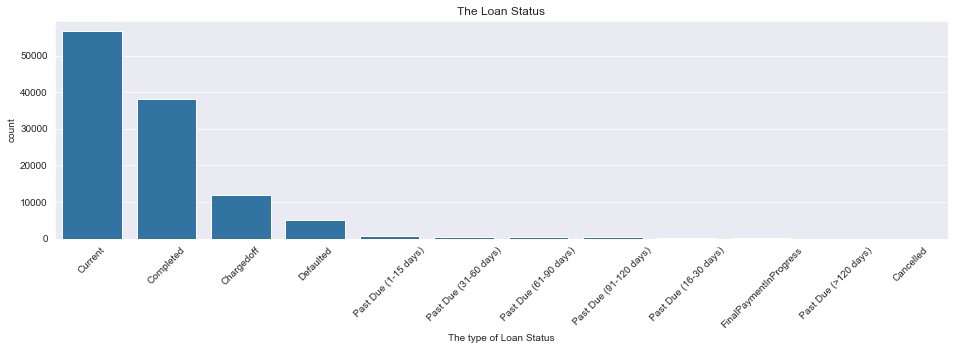

```python
plt.figure(figsize = [16,4])
order3 = df2['LoanStatus'].value_counts().index
sn.countplot(data = df2 , x = 'LoanStatus' , color =basecolor , order=order3);
plt.xticks(rotation = 45);
plt.title('The Loan Status')
plt.xlabel('The type of Loan Status')
plt.ylabel('count')
plt.show()
```

What are the top 5 and bottom 5 occupation type of the borrowerw?

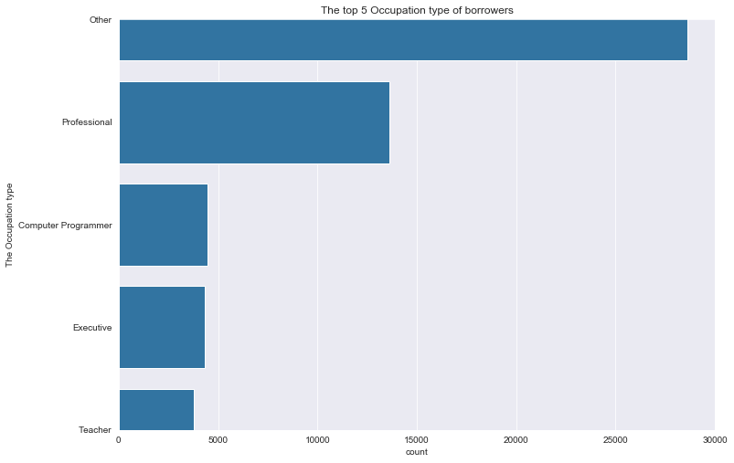

```python
plt.figure(figsize = [11.69,8.27])
order4 = df2['Occupation'].value_counts().index

ax=sn.countplot(data = df2 , y = 'Occupation' , color =basecolor , order = order4);
ax= ax.set(xlim=(0,30000),ylim=(4, 0))
plt.title('The top 5 Occupation type of borrowers')
plt.xlabel('count')
plt.ylabel('The Occupation type')
plt.show()
```

[figure not shown]

```python
plt.figure(figsize = [11.29,8.67])
order4 = df2['Occupation'].value_counts().index

ax=sn.countplot(data = df2 , y = 'Occupation' , color =basecolor , order = order4);
ax= ax.set(xlim=(0,30000),ylim=(67, 62))
plt.title('The bottom 5 Occupation type of borrower')
plt.xlabel('count')
plt.ylabel('The Occupation type')
plt.show()
```

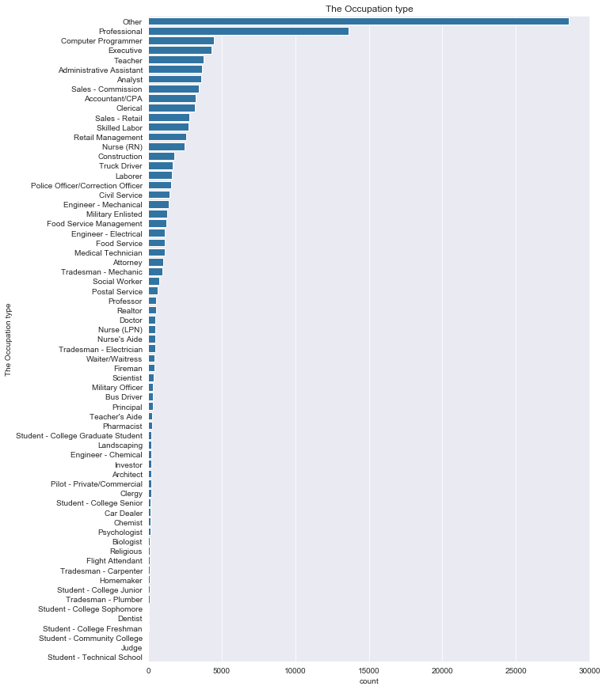

```python
plt.figure(figsize = [10,15])
order4 = df2['Occupation'].value_counts().index
sn.countplot(data = df2 , y = 'Occupation' , color =basecolor , order = order4);
plt.title('The Occupation type')
plt.xlabel('count')
plt.ylabel('The Occupation type')
plt.show()
```

The highest occupation type for the borrower is others and then Professional, Computer Programmer, Executive.

Is the borrower a home owner? Actually about 50% of the borrower a home owner

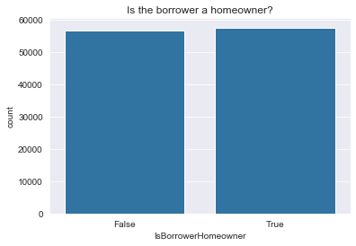

```python
sn.countplot(data = df2 , x = 'IsBorrowerHomeowner' , color =basecolor);
plt.title('Is the borrower a homeowner?')

plt.show()
```

About 50% of the borrower a home owner

Which states of people borrow the most? People who live in California actually borrow the loan the most. New York, Texas and Florida are the next highest.

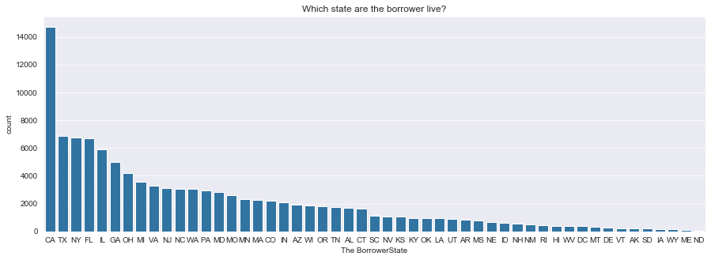

```python
#10 The borrower State,  Where are these Borrower live?

plt.figure(figsize=(15,5))
order5 = df2['BorrowerState'].value_counts().index
sn.countplot(data = df2 , x = 'BorrowerState' , color =basecolor , order = order5);
plt.title('Which state are the borrower live?')
plt.xlabel('The BorrowerState')

plt.show()
```

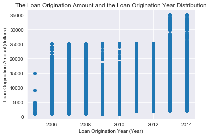

```python
#2  Loan Origination year v.s Loan Origination Amount

plt.scatter(data = df2 , x= 'OriginationYear' , y = 'LoanOriginalAmount');

plt.title('The Loan Origination Amount and the Loan Origination Year Distribution')
plt.xlabel('Loan Origination Year (Year)')
plt.ylabel('Loan Origination Amount(dollars)')
plt.show()
```

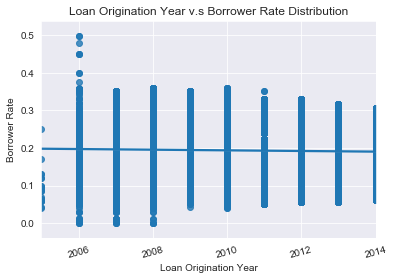

```python
sn.regplot(data = df2, x = 'OriginationYear', y = 'BorrowerRate',color = basecolor);
plt.xticks(rotation = 15);
plt.title('Loan Origination Year v.s Borrower Rate Distribution')
plt.xlabel('Loan Origination Year')
plt.ylabel('Borrower Rate')
plt.show()
```

The borrowers who income is $100,000 have the lowest borrower rate. The borrowers who are not employed have the highest borrower APR and then the second highest borrower APR are the borrowers who income range are below 24,999

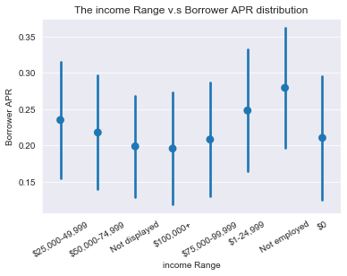

```python
#5 Income Range v.s Borrower APR
sn.pointplot(data = df2, x = 'IncomeRange', y = 'BorrowerAPR', linestyles = '' , ci = 'sd');
plt.xticks(rotation = 30);
plt.title('The income Range v.s Borrower APR distribution')
plt.xlabel('income Range')
plt.ylabel('Borrower APR')
plt.show()
```